# Análisis de Anotaciones GO de la inversión $U_8$ de *Drosophila subobscura*

Mercè Merayo Pastor

10-12-2024

# Introducción

Este documento analiza las anotaciones GO obtenidas del archivo `.gaf` del genoma de referencia `Genome assembly UCBerk_Dsub_1.0` de *Drosophila subobscura*.

Se agrupan los **Procesos biológicos**, **Funciones moleculares**, y **Componentes celulares** más frecuentes para la invesión $U_8$ tanto en las regiones flanqueantes de los puntos de rotura encontrados con Breakdancer y validados parcialmente tras realizar un ensamblaje *de novo* en la cepa OF58, como en la región interna de la inversión.

Inicialmente se ha encontrado una invesión con Breakdancer compatible con la inversión $U_8$ con los puntos de rotura en las coordenadas del genoma de referencia de *Drosophila subobscura* 7.772.887 y 14.722.269.

# Preparación de Datos

```r
# Leer los datos del archivo procesado
datos_anotaciones_U <- read.csv("anotaciones_estudio_coord_U.csv", header = FALSE, stringsAsFactors = FALSE)
colnames(datos_anotaciones_U) <- c("Gen", "Cromosoma", "Inicio", "Fin", "GO_ID", "Tipo")
```

Agregar las descripciones de los términos GO (Gene Ontology) desde la base de datos `GO.db`.

```r
# Crear una nueva columna con las descripciones
datos_anotaciones_U$Descripcion_GO <- sapply(datos_anotaciones_U$GO_ID, function(go_id) {
  # Extraer la descripción desde GO.db
  Term(go_id)
})

datos_anotaciones_U$Definicion_GO <- sapply(datos_anotaciones_U$GO_ID, function(go_id) {
  # Extraer la definición desde GO.db
  Definition(go_id)
})
```

Carga de las anotaciones del genoma de referecia de *Dosophila subobscura* a partir de la descarga de la tabla .tsv desde [https://www.ncbi.nlm.nih.gov/datasets/gene/GCF_008121235.1/].

```r
genes_anotados_Dsub <- read.csv("genes_anotados_Dsubobscura.csv", header=TRUE, stringsAsFactors = FALSE)
genes_anotados_Dsub_U <- genes_anotados_Dsub %>% filter(Accession == "NC_048534.1")
```

```r
datos_anotaciones_U <- datos_anotaciones_U %>%
  left_join(genes_anotados_Dsub %>% dplyr::select(Symbol, Name), by = c("Gen" = "Symbol"))
```

```r
datos_anotaciones_U <- datos_anotaciones_U %>% distinct()
```

Se filtran las anotaciones por las tres categorías principales de Gene Ontology.

```r
Proceso_biologico <- datos_anotaciones_U %>% filter(Tipo == "P")
Funcion_molecular <- datos_anotaciones_U %>% filter(Tipo == "F")
Componente_celular <- datos_anotaciones_U %>% filter(Tipo == "C")
```

Se definen los puntos de rotura la inversión $U_8$ detectados por Breakdancer para filtrar toda la región interna de la inversión.

```r
punto_proximal <- 7772887
#punto_distal <- 14722269
punto_distal <- 14721766
```

```r
Proceso_biologico_U8 <- Proceso_biologico %>% filter(Inicio >= punto_proximal & Fin <= punto_distal)
Funcion_molecular_U8 <- Funcion_molecular %>% filter(Inicio >= punto_proximal & Fin <= punto_distal)
Componente_celular_U8 <- Componente_celular %>% filter(Inicio >= punto_proximal & Fin <= punto_distal)
```

# Resultados

## Procesos Biológicos dentro de la inversión $U_8$

```r
# Contar la frecuencia de cada descripción
tabla_proce_bio_U8 <- Proceso_biologico_U8 %>%
  count(Descripcion_GO, sort = TRUE)

# La Descripcion se convierte a factor para ordenar las barras por frecuencia más adelante
tabla_proce_bio_U8 <- tabla_proce_bio_U8 %>%
  mutate(Descripcion_GO = factor(Descripcion_GO, levels = rev(unique(Descripcion_GO))))

num_procesos_bio_U8 <- n_distinct(Proceso_biologico_U8$Descripcion_GO) # Se evitan la repeticiones

paste("Hay", num_procesos_bio_U8, "procesos biológicos diferente en los genes de la región U8.")
```

```
## [1] "Hay 410 procesos biológicos diferente en los genes de la región U8."
```

```r
# Filtrar los conceptos más frecuentes en este caso 15
top_n <- 15
tabla_proce_bio_U8_top15 <- tabla_proce_bio_U8 %>%
  slice_max(n, n = top_n)

tabla_proce_bio_U8_top15_orden <- tabla_proce_bio_U8_top15 %>%
  mutate(Descripcion_GO = factor(Descripcion_GO, levels = rev(unique(Descripcion_GO)))) %>%
  filter(!is.na(Descripcion_GO))
```

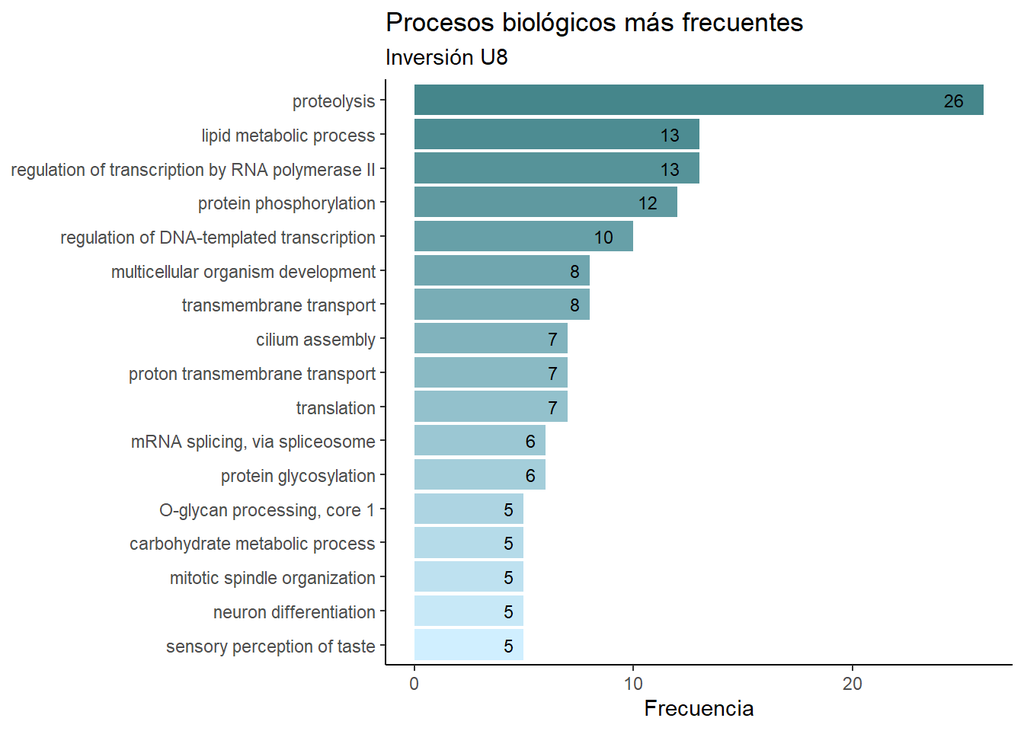

```r
color_palette <- colorRampPalette(c("#D0EFFF", "#45868B"))(nrow(tabla_proce_bio_U8_top15_orden))


graf_proc_bio_U8 <- ggplot(tabla_proce_bio_U8_top15_orden, aes(x = Descripcion_GO, y = n, fill = Descripcion_GO)) +
  geom_bar(stat = "identity" ) +
  geom_text(aes(label = n), hjust = 2, size = 3) +
  labs(title = "Procesos biológicos más frecuentes",subtitle = "Inversión U8", y = "Frecuencia", x = NULL) +
  scale_fill_manual(values = color_palette) +
  coord_flip() +
  theme_classic()+
  theme(legend.position = "none")
graf_proc_bio_U8
```

## Funciones Moleculares

```r
# Contar la frecuencia de cada descripción
tabla_fun_molec_U8 <- Funcion_molecular_U8 %>%
  count(Descripcion_GO, sort = TRUE)

# La Descripcion se convierte a factor para ordenar las barras por frecuencia más adelante
tabla_fun_molec_U8 <- tabla_fun_molec_U8 %>%
  mutate(Descripcion_GO = factor(Descripcion_GO, levels = rev(unique(Descripcion_GO))))

num_fun_molec_U8 <- n_distinct(Funcion_molecular_U8$Descripcion_GO)

paste("Hay", num_fun_molec_U8, "funciones moleculares diferentes en los genes de la región U_8.")
```

```
## [1] "Hay 315 funciones moleculares diferentes en los genes de la región U_8."
```

```r
# Filtrar los conceptos más frecuentes
tabla_fun_molec_U8_top15 <- tabla_fun_molec_U8 %>%
  slice_max(n, n = top_n)

tabla_fun_molec_U8_top15_orden <- tabla_fun_molec_U8_top15 %>%
  mutate(Descripcion_GO = factor(Descripcion_GO, levels = rev(unique(Descripcion_GO)))) %>%
  filter(!is.na(Descripcion_GO))
```

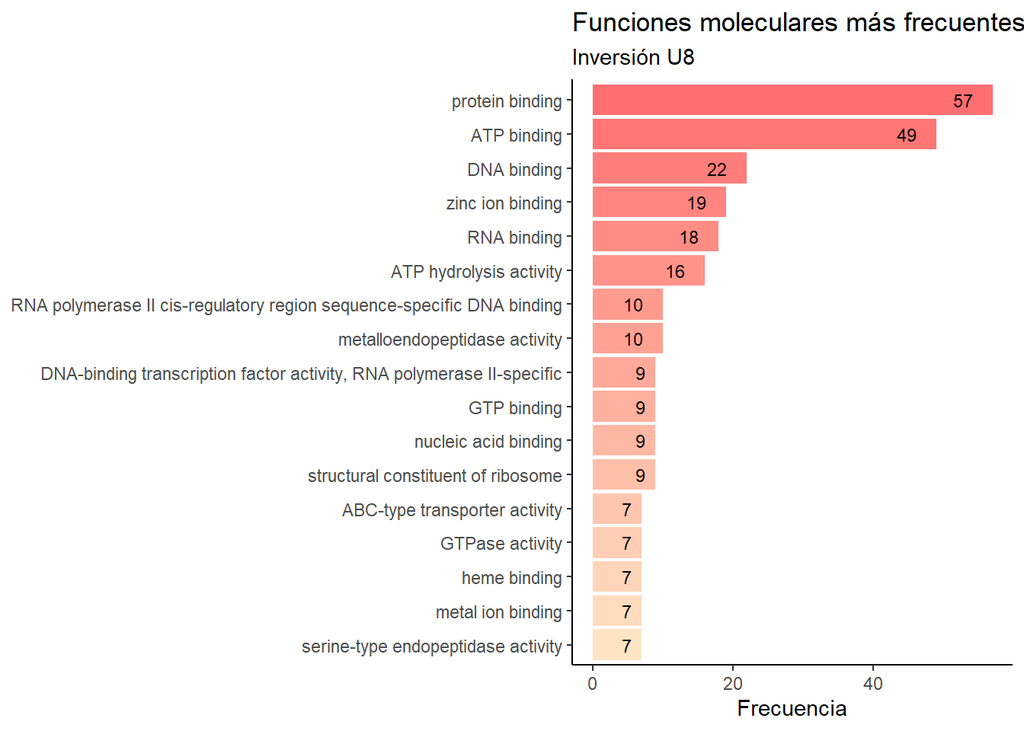

```r
color_palette <- colorRampPalette(c("#FFE4C4", "#FF6F70"))(nrow(tabla_fun_molec_U8_top15_orden))


graf_fun_molec_U8 <- ggplot(tabla_fun_molec_U8_top15_orden, aes(x = Descripcion_GO, y = n, fill = Descripcion_GO)) +
  geom_bar(stat = "identity" ) +
  geom_text(aes(label = n), hjust = 2, size = 3) +
  labs(title = "Funciones moleculares más frecuentes", subtitle = "Inversión U8",y = "Frecuencia", x = NULL) +
  scale_fill_manual(values = color_palette) +
  coord_flip() +
  theme_classic()+
  theme(legend.position = "none")
graf_fun_molec_U8
```

## Componentes Celulares

```r
# Contar la frecuencia de cada descripción
tabla_componente_U8 <- Componente_celular_U8 %>%
  count(Descripcion_GO, sort = TRUE)

# Convertir la Descripcion_GO a factor para ordenar las barras por frecuencia
tabla_componente_U8 <- tabla_componente_U8 %>%
  mutate(Descripcion_GO = factor(Descripcion_GO, levels = rev(unique(Descripcion_GO))))

num_componente_U8 <- n_distinct(Componente_celular_U8$Descripcion_GO)

# Generar el mensaje
paste("Hay", num_componente_U8, "componentes celulares diferentes en los genes de la región U_8.")
```

```
## [1] "Hay 227 componentes celulares diferentes en los genes de la región U_8."
```

```r
# Componentes celulares más frecuentes en la inversión U_8
tabla_componente_U8_top15 <- tabla_componente_U8 %>%
  slice_max(n, n = top_n)

tabla_componente_U8_top15_orden <- tabla_componente_U8_top15 %>%
  mutate(Descripcion_GO = factor(Descripcion_GO, levels = rev(unique(Descripcion_GO)))) %>%
  filter(!is.na(Descripcion_GO))
```

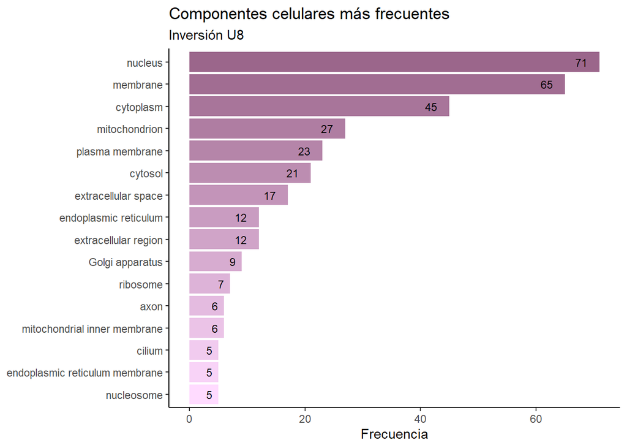

```r
color_palette <- colorRampPalette(c("#FFDBFF","#9B668B"))(nrow(tabla_componente_U8_top15_orden))


graf_comp_U8 <- ggplot(tabla_componente_U8_top15_orden, aes(x = Descripcion_GO, y = n, fill = Descripcion_GO)) +
  geom_bar(stat = "identity" ) +
  geom_text(aes(label = n), hjust = 2, size = 3) +
  labs(title = "Componentes celulares más frecuentes", subtitle = "Inversión U8", y = "Frecuencia", x = NULL) +
  scale_fill_manual(values = color_palette) +
  coord_flip() +
  theme_classic()+
  theme(legend.position = "none")
graf_comp_U8
```

## Regiones flanqueantes de los puntos de rotura

### Tablas región flanqueante proximal

```r
datos_anotaciones_U8_proximal <- datos_anotaciones_U %>% filter(Inicio >= (punto_proximal - 5000) & Fin <= (punto_proximal + 5000))
```

```r
library(kableExtra)

tabla_proximal <- datos_anotaciones_U8_proximal %>%
  mutate(Coordenadas = paste0(Inicio, "-", Fin)) %>%  # Crear la columna de coordenadas
  group_by(Gen, Name, Coordenadas) %>%  # Agrupar por Gen, Name y Coordenadas
  summarise(
    Funciones_Moleculares = paste0(
      unique(paste(GO_ID[Tipo == "F"], Descripcion_GO[Tipo == "F"], sep = ": ")),
      collapse = "; "
    ),
    Procesos_Biologicos = paste0(
      unique(paste(GO_ID[Tipo == "P"], Descripcion_GO[Tipo == "P"], sep = ": ")),
      collapse = "; "
    ),
    Componentes_Celulares = paste0(
      unique(paste(GO_ID[Tipo == "C"], Descripcion_GO[Tipo == "C"], sep = ": ")),
      collapse = "; "
    )
  ) %>%
  ungroup() %>%
  mutate(
    Gen_Nombre = paste0(Gen, " - ", Name)  # Combinar Gen y Name en una sola celda
  ) %>%
  dplyr::select(Gen_Nombre, Coordenadas, Funciones_Moleculares, Procesos_Biologicos, Componentes_Celulares)  %>%
  arrange(as.numeric(sub("-.*", "", Coordenadas)))
```

```r
# Reemplazar el separador ";" por saltos de línea en HTML
tabla_proximal <- tabla_proximal %>%
  mutate(
    Funciones_Moleculares = gsub("; ", "<br>", Funciones_Moleculares),
    Procesos_Biologicos = gsub("; ", "<br>", Procesos_Biologicos),
    Componentes_Celulares = gsub("; ", "<br>", Componentes_Celulares)
  )


tabla_proximal %>%
  kable(
    format = "html",
    escape = FALSE,  # Necesario para procesar HTML como <br>
    col.names = c("Gen / Nombre de la proteína", "Coordenadas genómicas", "Funciones Moleculares",
                  "Procesos Biológicos", "Componentes Celulares"),
    caption = "Términos GO de los genes situados cerca del punto de rotura proximal de la inversión U_8"
  )
```

Términos GO de los genes situados cerca del punto de rotura proximal de la inversión U_8

| Gen / Nombre de la proteína | Coordenadas genómicas | Funciones Moleculares | Procesos Biológicos | Componentes Celulares |
| --- | --- | --- | --- | --- |
| LOC117900743 - thyrostimulin beta-5 subunit | 7770494-7771257 | GO:0005179: hormone activity | GO:0007186: G protein-coupled receptor signaling pathway | GO:0005576: extracellular region GO:0005615: extracellular space GO:0005737: cytoplasm |
| LOC117900742 - mitochondrial import inner membrane translocase subunit Tim23 | 7771342-7772481 | GO:0008320: protein transmembrane transporter activity | GO:0030150: protein import into mitochondrial matrix | GO:0005743: mitochondrial inner membrane GO:0005744: TIM23 mitochondrial import inner membrane translocase complex |
| LOC117900741 - uncharacterized protein YJR142W isoform X1 | 7773180-7777052 | GO:0044715: 8-oxo-dGDP phosphatase activity |  |  |

### Tablas región flanqueante distal

```r
datos_anotaciones_U8_distal <- datos_anotaciones_U %>% filter(Inicio >= (punto_distal - 5000) & Fin <= (punto_distal + 5000))
```

```r
tabla_distal <- datos_anotaciones_U8_distal %>%
  mutate(Coordenadas = paste0(Inicio, "-", Fin)) %>%  # Columna de coordenadas
  group_by(Gen, Name, Coordenadas) %>%  # Agrupar por Gen, Name y Coordenadas
  summarise(
    Funciones_Moleculares = paste0(
      unique(paste(GO_ID[Tipo == "F"], Descripcion_GO[Tipo == "F"], sep = ": ")),
      collapse = "; "
    ),
    Procesos_Biologicos = paste0(
      unique(paste(GO_ID[Tipo == "P"], Descripcion_GO[Tipo == "P"], sep = ": ")),
      collapse = "; "
    ),
    Componentes_Celulares = paste0(
      unique(paste(GO_ID[Tipo == "C"], Descripcion_GO[Tipo == "C"], sep = ": ")),
      collapse = "; "
    )
  ) %>%
  ungroup() %>%
  mutate(
    Gen_Nombre = paste0(Gen, " - ", Name)  # Combinar Gen y Name en una sola celda
  ) %>%
  dplyr::select(Gen_Nombre, Coordenadas, Funciones_Moleculares, Procesos_Biologicos, Componentes_Celulares) %>%
  arrange(as.numeric(sub("-.*", "", Coordenadas)))
```

```r
tabla_distal <- tabla_distal %>%
  mutate(
    Funciones_Moleculares = gsub("; ", "<br>", Funciones_Moleculares),
    Procesos_Biologicos = gsub("; ", "<br>", Procesos_Biologicos),
    Componentes_Celulares = gsub("; ", "<br>", Componentes_Celulares)
  )

tabla_distal %>%
  kable(
    col.names = c("Gen / Nombre de la proteína", "Coordenadas genómicas", "Funciones Moleculares",
                  "Procesos Biológicos", "Componentes Celulares"),
    caption = "Términos GO de los genes situados cerca del punto de rotura distal de la inversión U_8"
  )
```

Términos GO de los genes situados cerca del punto de rotura distal de la inversión U_8

| Gen / Nombre de la proteína | Coordenadas genómicas | Funciones Moleculares | Procesos Biológicos | Componentes Celulares |
| --- | --- | --- | --- | --- |
| LOC117901749 - protoheme IX farnesyltransferase, mitochondrial | 14716960-14718751 | GO:0008495: protoheme IX farnesyltransferase activity | GO:0006783: heme biosynthetic process | GO:0005739: mitochondrion GO:0016020: membrane |
| LOC117901454 - cilia- and flagella-associated protein 20 isoform X1 | 14719090-14720090 |  | GO:0060271: cilium assembly GO:0060296: regulation of cilium beat frequency involved in ciliary motility GO:2000147: positive regulation of cell motility | GO:0031514: motile cilium GO:0036064: ciliary basal body |
| LOC117901453 - methionine aminopeptidase 1D, chloroplastic/mitochondrial | 14720021-14721256 | GO:0070006: metalloaminopeptidase activity | GO:0006508: proteolysis |  |
| LOC117901760 - leucine-rich repeat-containing protein 15 | 14722075-14724843 | GO:0005515: protein binding |  | GO:0005615: extracellular space GO:0031012: extracellular matrix |

### Genes que contienen algun punto de rotura

```r
genes_en_punto_rotura <- datos_anotaciones_U %>%
  filter((punto_proximal >= Inicio & punto_proximal <= Fin) | (punto_distal >= Inicio & punto_distal <= Fin))
kable(genes_en_punto_rotura)
```

| Gen | Cromosoma | Inicio | Fin | GO_ID | Tipo | Descripcion_GO | Definicion_GO | Name |
| --- | --- | --- | --- | --- | --- | --- | --- | --- |

## Exploración de genes relacionados con la adaptación térmica en la inversión $U_8$

Se analiza la inversión cromosómica $U_8$ en la que se busca identificar genes asociados a la adaptación térmica dentro de esta región. Basado en el artículo de Antunes et al. (2024), que enumera genes involucrados en procesos como proteólisis, metabolismo de lípidos y plasticidad adaptativa, se quiere determinar si alguno de estos genes está presente en la región que en este TFM se ha identificado como la inversió $U_8$.

```r
genes_Antunes <- read.csv("GeneID_Antunes_paper.csv", stringsAsFactors = FALSE)
```

Se buscan las coincidencias de genes listados en el artículo.

```r
genesU8_coincidentes <- datos_anotaciones_U %>%
  filter(Gen %in% genes_Antunes$GeneID_Antunes)
```

```r
genesU8_Antunes <- genesU8_coincidentes %>%
  mutate(Coordenadas = paste0(Inicio, "-", Fin)) %>%  # Columna de coordenadas
  group_by(Gen, Name, Coordenadas) %>%  # Agrupar por Gen, Name y Coordenadas
  summarise(
    Funciones_Moleculares = paste0(
      unique(paste(GO_ID[Tipo == "F"], Descripcion_GO[Tipo == "F"], sep = ": ")),
      collapse = "; "
    ),
    Procesos_Biologicos = paste0(
      unique(paste(GO_ID[Tipo == "P"], Descripcion_GO[Tipo == "P"], sep = ": ")),
      collapse = "; "
    ),
    Componentes_Celulares = paste0(
      unique(paste(GO_ID[Tipo == "C"], Descripcion_GO[Tipo == "C"], sep = ": ")),
      collapse = "; "
    )
  ) %>%
  ungroup() %>%
  mutate(
    Gen_Nombre = paste0(Gen, " - ", Name)  # Combinar Gen y Name en una sola celda
  ) %>%
  dplyr::select(Gen_Nombre, Coordenadas, Funciones_Moleculares, Procesos_Biologicos, Componentes_Celulares) %>%
  arrange(as.numeric(sub("-.*", "", Coordenadas)))
```

```r
tabla_genesU8_Antunes <- genesU8_Antunes %>%
  mutate(
    Funciones_Moleculares = gsub("; ", "<br>", Funciones_Moleculares),
    Procesos_Biologicos = gsub("; ", "<br>", Procesos_Biologicos),
    Componentes_Celulares = gsub("; ", "<br>", Componentes_Celulares)
  )

tabla_genesU8_Antunes %>%
  kable(
    col.names = c("Gen / Nombre de la proteína", "Coordenadas genómicas", "Funciones Moleculares",
                  "Procesos Biológicos", "Componentes Celulares"),
    caption = "Términos GO de los genes relacionados con la adaptación térmica"
  )
```

Términos GO de los genes relacionados con la adaptación térmica

| Gen / Nombre de la proteína | Coordenadas genómicas | Funciones Moleculares | Procesos Biológicos | Componentes Celulares |
| --- | --- | --- | --- | --- |
| LOC117902436 - zinc finger BED domain-containing protein 4 isoform X1 | 8251059-8253193 | GO:0003677: DNA binding |  |  |
| LOC117902220 - DNA-directed RNA polymerases I and III subunit RPAC1 | 13174198-13175420 | GO:0001054: RNA polymerase I activity GO:0001056: RNA polymerase III activity GO:0046983: protein dimerization activity | GO:0006351: DNA-templated transcription | GO:0005666: RNA polymerase III complex GO:0005736: RNA polymerase I complex |